# transitiontrees on the trajectories data

One analysis, its default output, and how to read it — nothing more

transitiontrees

2026-06-05

This is a plain walk-through of `transitiontrees` on the built-in `trajectories` data. Every step is a single **default call** — no subsetting, no tuning, no clever code. Each section is one analysis, its default output or plot, and a short reading.

# The data

```r
data(trajectories)            # bundled with transitiontrees
dim(trajectories)
```

```
#> [1] 138  15
```

```r
head(trajectories)
```

```
#>      1         2            3            4            5            6
#> [1,] "Active"  "Disengaged" "Disengaged" "Disengaged" "Active"     "Active"
#> [2,] "Average" "Average"    "Average"    "Average"    "Average"    "Average"
#> [3,] "Average" "Active"     "Active"     "Active"     "Active"     "Active"
#> [4,] "Active"  "Active"     "Active"     "Active"     "Active"     "Average"
#> [5,] "Active"  "Active"     "Active"     "Average"    "Active"     "Average"
#> [6,] "Average" "Average"    "Disengaged" "Average"    "Disengaged" "Disengaged"
#>      7         8         9         10           11        12
#> [1,] "Active"  "Active"  "Average" "Active"     "Average" "Active"
#> [2,] "Average" "Average" "Average" "Active"     "Average" "Average"
#> [3,] "Active"  "Active"  "Active"  "Average"    "Active"  "Active"
#> [4,] "Average" "Active"  "Active"  "Active"     "Average" "Active"
#> [5,] "Active"  "Active"  "Active"  "Disengaged" "Active"  "Active"
#> [6,] "Average" "Average" "Average" "Disengaged" "Average" "Disengaged"
#>      13        14        15
#> [1,] NA        NA        NA
#> [2,] "Average" "Average" "Average"
#> [3,] "Active"  "Active"  "Active"
#> [4,] "Average" "Active"  "Average"
#> [5,] "Active"  "Average" "Average"
#> [6,] "Average" "Average" "Average"
```

> One row per learner, one column per time-step, three engagement states (`Active`, `Average`, `Disengaged`). Trailing `NA`s mark the end of a trajectory. This wide frame is exactly what `context_tree()` consumes.

# Fit a context tree

```r
tree <- context_tree(trajectories)
tree
```

```
#> <transitiontrees>  145 nodes, depth <= 5, 3 states  [unpruned]
#>   alphabet : Active, Average, Disengaged
#>   fit on   : 136 sequences, 1870 observations
#>   smoothing: floor(ymin=0.001, rule=interpolate)   min_count = 5
#> (start)   n=1870   -> Average (0.43)
#> |-- Active    n=658    -> Active (0.70)
#> |   |-- Active    n=433    -> Active (0.79)
#> |   |   |-- Active    n=316    -> Active (0.84)
#> |   |   |   |-- Active    n=240    -> Active (0.87)
#> |   |   |   |   |-- Active    n=192    -> Active (0.87)
#> |   |   |   |   |-- Average   n=17     -> Active (0.76)
#> |   |   |   |   `-- Disengaged  n=7      -> Active (0.71)
#> |   |   |   |-- Average   n=37     -> Active (0.59)
#> |   |   |   |   |-- Active    n=12     -> Active (0.83)
#> |   |   |   |   `-- Average   n=18     -> Active (0.50)
#> |   |   |   `-- Disengaged  n=10     -> Active (0.90)
#> |   |   |       `-- Active    n=5      -> Active (0.80)
#> |   |   |-- Average   n=70     -> Active (0.53)
#> |   |   |   |-- Active    n=22     -> Active (0.55)
#> |   |   |   |   |-- Active    n=11     -> Active (0.64)
#> |   |   |   |   `-- Average   n=10     -> Average (0.50)
#> |   |   |   `-- Average   n=37     -> Active (0.49)
#> |   |   |       |-- Active    n=15     -> Active (0.53)
#> |   |   |       |-- Average   n=15     -> Active (0.47)
#> |   |   |       `-- Disengaged  n=7      -> Average (0.57)
#> |   |   `-- Disengaged  n=15     -> Active (0.67)
#> |   |       |-- Active    n=5      -> Active (1.00)
#> |   |       `-- Average   n=7      -> Average (0.57)
#> |   |-- Average   n=144    -> Active (0.50)
#> |   |   |-- Active    n=53     -> Average (0.55)
#> ... 119 more nodes (use as.data.frame(x) or summary(x))
```

> The banner is the whole model at a glance: how many contexts it holds, the alphabet, how many sequences and observations it was fit on, and — at the bottom — the next state predicted from no history (the `(start)` row) followed by the tree of deeper contexts. With the defaults the tree grows to depth 5, so it is large and over-grown; the next step trims it.

# Prune the tree

```r
pruned <- prune_tree(tree)
pruned
```

```
#> <transitiontrees>  32 nodes, depth <= 5, 3 states  [pruned]
#>   alphabet : Active, Average, Disengaged
#>   fit on   : 136 sequences, 1870 observations
#>   smoothing: floor(ymin=0.001, rule=interpolate)   min_count = 5
#>   pruned by: G2   alpha = 0.05
#> (start)   n=1870   -> Average (0.43)
#> |-- Active    n=658    -> Active (0.70)
#> |   |-- Active    n=433    -> Active (0.79)
#> |   |   |-- Active    n=316    -> Active (0.84)
#> |   |   |   `-- Average   n=37     -> Active (0.59)
#> |   |   `-- Average   n=70     -> Active (0.53)
#> |   `-- Average   n=144    -> Active (0.50)
#> |       `-- Disengaged  n=12     -> Average (0.83)
#> |-- Average   n=751    -> Average (0.61)
#> |   |-- Active    n=160    -> Average (0.52)
#> |   |   |-- Active    n=74     -> Average (0.55)
#> |   |   |   `-- Active    n=40     -> Active (0.53)
#> |   |   |       `-- Average   n=13     -> Active (0.77)
#> |   |   `-- Disengaged  n=10     -> Average (0.50)
#> |   |-- Average   n=419    -> Average (0.68)
#> |   |   |-- Active    n=80     -> Average (0.57)
#> |   |   |   `-- Active    n=38     -> Average (0.50)
#> |   |   |       `-- Active    n=13     -> Active (0.61)
#> |   |   `-- Average   n=248    -> Average (0.72)
#> |   |       |-- Average   n=148    -> Average (0.74)
#> |   |       |   `-- Active    n=24     -> Average (0.71)
#> |   |       `-- Disengaged  n=37     -> Average (0.70)
#> |   `-- Disengaged  n=122    -> Average (0.52)
#> |       `-- Disengaged  n=31     -> Average (0.71)
#> `-- Disengaged  n=325    -> Disengaged (0.48)
#>     |-- Active    n=23     -> Active (0.39)
#> ... 6 more nodes (use as.data.frame(x) or summary(x))
```

> The default fit above grows all the way to depth 5 and keeps deep contexts the data barely supports (over-fitting). Pruning keeps a longer history only when it predicts better than its shorter version, so the tree gets much smaller — the banner now reads `pruned by: G2`. The rest of the vignette uses this pruned tree.

# Draw the tree

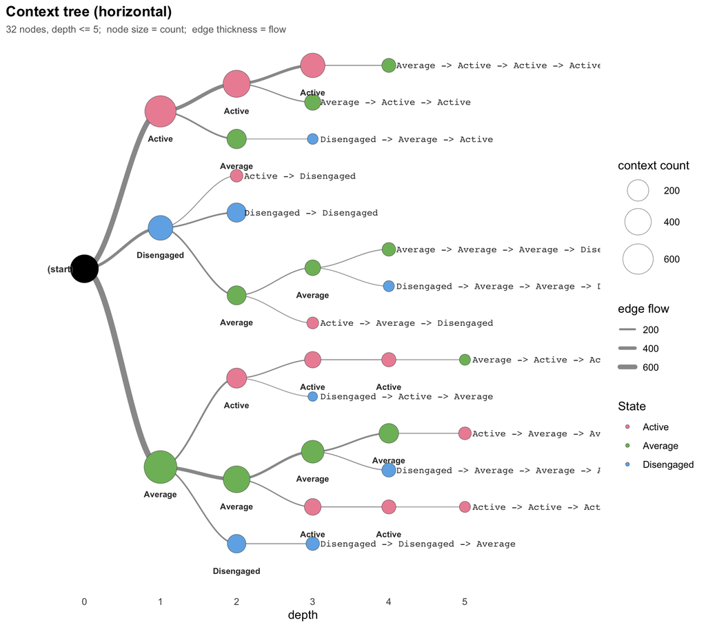

```r
plot(pruned)
```

> The default picture: a left-to-right tree. **Node size** is how often a context occurs, **branch thickness** is the volume flowing down it, and **colour** is the most recent state. The thick branches are the common engagement patterns; the thin twigs are the rarer contexts pruning kept on evidence.

# Most common pathways

```r
common_pathways(pruned)
```

|  | pathway | depth | count | likely_next | next_probability | divergence | changes_prediction |
| --- | --- | --- | --- | --- | --- | --- | --- |
| 1 | (start) | 0 | 1870 | Average | 0.4347594 | NA | NA |
| 2 | Average | 1 | 751 | Average | 0.6098535 | 0.113562458 | FALSE |
| 3 | Active | 1 | 658 | Active | 0.6975684 | 0.349487162 | TRUE |
| 4 | Active -> Active | 2 | 433 | Active | 0.7852194 | 0.028601567 | FALSE |
| 5 | Average -> Average | 2 | 419 | Average | 0.6778043 | 0.014667961 | FALSE |
| 6 | Disengaged | 1 | 325 | Disengaged | 0.4830769 | 0.403065556 | TRUE |
| 7 | Active -> Active -> Active | 3 | 316 | Active | 0.8354430 | 0.011491875 | FALSE |
| 8 | Average -> Average -> Average | 3 | 248 | Average | 0.7177419 | 0.006242261 | FALSE |
| 9 | Active -> Average | 2 | 160 | Average | 0.5187500 | 0.122825881 | FALSE |
| 10 | Average -> Average -> Average -> Average | 4 | 148 | Average | 0.7432432 | 0.004594702 | FALSE |

> The trajectories the data simply contains the most copies of, ranked by count. `likely_next` and `next_probability` say what tends to come after each — the everyday flow of engagement.

# Most divergent pathways

```r
divergent_pathways(pruned)
```

|  | pathway | depth | count | likely_next | next_probability | divergence | changes_prediction |
| --- | --- | --- | --- | --- | --- | --- | --- |
| 1 | Disengaged -> Average -> Average -> Disengaged | 4 | 13 | Disengaged | 0.8461538 | 0.6883259 | TRUE |
| 2 | Disengaged -> Active -> Average | 3 | 10 | Average | 0.5000000 | 0.5477701 | FALSE |
| 3 | Disengaged | 1 | 325 | Disengaged | 0.4830769 | 0.4030656 | TRUE |
| 4 | Average -> Active -> Active -> Active -> Average | 5 | 13 | Active | 0.7692308 | 0.4004254 | FALSE |
| 5 | Disengaged -> Average -> Active | 3 | 12 | Average | 0.8318333 | 0.3933342 | TRUE |
| 6 | Active -> Active -> Active -> Average -> Average | 5 | 13 | Active | 0.6145385 | 0.3662758 | TRUE |
| 7 | Active | 1 | 658 | Active | 0.6975684 | 0.3494872 | TRUE |
| 8 | Active -> Disengaged | 2 | 23 | Active | 0.3913043 | 0.3478095 | TRUE |
| 9 | Active -> Average -> Disengaged | 3 | 17 | Active | 0.4117647 | 0.3132959 | TRUE |
| 10 | Active -> Average -> Average -> Average -> Average | 5 | 24 | Average | 0.7072083 | 0.2664126 | FALSE |

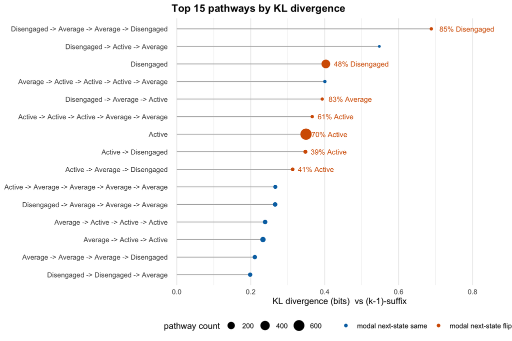

```r
plot_divergence(pruned)
```

> These are the contexts where knowing the longer history **changes the prediction most** (the `divergence` column, drawn as the lollipop). Orange points mark pathways where the extra history actually flips which state is most likely — the genuinely informative histories, as opposed to the merely common ones above.

# Sharpest pathways

```r
sharp_pathways(pruned)
```

|  | pathway | depth | count | likely_next | next_probability | divergence | changes_prediction |
| --- | --- | --- | --- | --- | --- | --- | --- |
| 1 | Disengaged -> Average -> Average -> Disengaged | 4 | 13 | Disengaged | 0.8461538 | 0.688325948 | TRUE |
| 2 | Active -> Active -> Active | 3 | 316 | Active | 0.8354430 | 0.011491875 | FALSE |
| 3 | Disengaged -> Average -> Active | 3 | 12 | Average | 0.8318333 | 0.393334181 | TRUE |
| 4 | Active -> Active | 2 | 433 | Active | 0.7852194 | 0.028601567 | FALSE |
| 5 | Average -> Active -> Active -> Active -> Average | 5 | 13 | Active | 0.7692308 | 0.400425432 | FALSE |
| 6 | Average -> Average -> Average -> Disengaged | 4 | 32 | Average | 0.7500000 | 0.211026397 | FALSE |
| 7 | Average -> Average -> Average -> Average | 4 | 148 | Average | 0.7432432 | 0.004594702 | FALSE |
| 8 | Average -> Average -> Average | 3 | 248 | Average | 0.7177419 | 0.006242261 | FALSE |
| 9 | Disengaged -> Disengaged -> Average | 3 | 31 | Average | 0.7085484 | 0.198404690 | FALSE |
| 10 | Active -> Average -> Average -> Average -> Average | 5 | 24 | Average | 0.7072083 | 0.266412604 | FALSE |

> Ranked by `next_probability`: the contexts whose next state is most nearly certain. High sharpness with a high `count` is a dependable rule; high sharpness on a small `count` is just chance, and the bootstrap section below separates the two.

# Per-context diagnostics

```r
tree_dependence(pruned)
```

| pathway | depth | count | divergence | entropy | entropy_before | entropy_drop | likely_next | likely_before | changes_prediction |
| --- | --- | --- | --- | --- | --- | --- | --- | --- | --- |
| Disengaged -> Average -> Average -> Disengaged | 4 | 13 | 0.688325948 | 0.7732283 | 1.3137762 | 0.540547878 | Disengaged | Average | TRUE |
| Disengaged -> Active -> Average | 3 | 10 | 0.547770136 | 1.3609640 | 1.3654995 | 0.004535442 | Average | Average | FALSE |
| Disengaged | 1 | 325 | 0.403065556 | 1.4032668 | 1.5076285 | 0.104361741 | Disengaged | Average | TRUE |
| Average -> Active -> Active -> Active -> Average | 5 | 13 | 0.400425432 | 0.9912643 | 1.2970893 | 0.305825000 | Active | Active | FALSE |
| Disengaged -> Average -> Active | 3 | 12 | 0.393334181 | 0.6623258 | 1.1249411 | 0.462615346 | Average | Active | TRUE |
| Active -> Active -> Active -> Average -> Average | 5 | 13 | 0.366275831 | 0.9718394 | 1.4498719 | 0.478032438 | Active | Average | TRUE |
| Active | 1 | 658 | 0.349487162 | 1.0404534 | 1.5076285 | 0.467175189 | Active | Average | TRUE |
| Active -> Disengaged | 2 | 23 | 0.347809514 | 1.5743318 | 1.4032668 | -0.171064986 | Active | Disengaged | TRUE |
| Active -> Average -> Disengaged | 3 | 17 | 0.313295862 | 1.5485652 | 1.4301429 | -0.118422293 | Active | Average | TRUE |
| Active -> Average -> Average -> Average -> Average | 5 | 24 | 0.266412604 | 0.8819341 | 1.0780562 | 0.196122066 | Average | Average | FALSE |

[output cut: 21 more lines]

> The information-theoretic view of each context: its `divergence`, its `entropy` (how uncertain its next state is), the parent’s `entropy_before`, and `entropy_drop` — how much uncertainty the context removes. A large `entropy_drop` with `changes_prediction = TRUE` is the most valuable kind of context: it both sharpens and redirects.

# Pathway × next-state heatmap

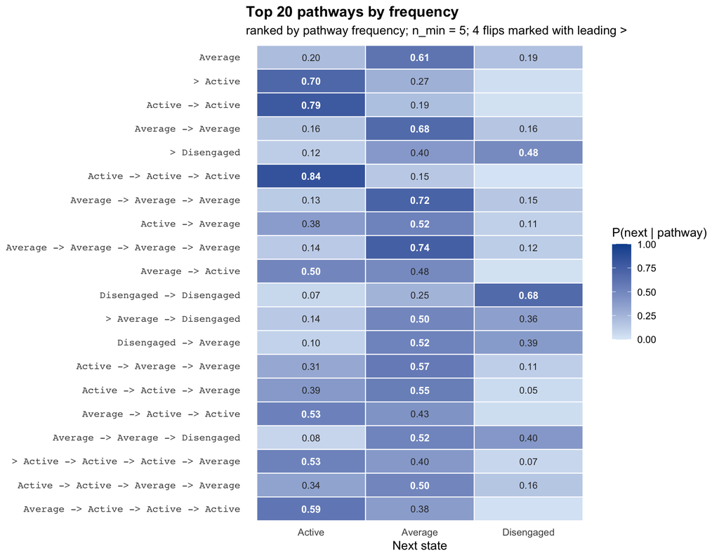

```r
plot_pathways(pruned)
```

# Goodness of fit

```r
model_fit(pruned)
```

| logLik | df | nobs | AIC | BIC | perplexity |
| --- | --- | --- | --- | --- | --- |
| -1491.713 | 64 | 1870 | 3111.425 | 3465.582 | 2.220444 |

> The standard scalars in one row. `perplexity` is the readable one — the effective number of equally-likely next states; against a uniform baseline of three states, the tree’s value shows how much the recent history narrows things down. `AIC`/`BIC` penalise the node count and let you weigh two candidate trees.

# Reliability under resampling

```r
boot <- bootstrap_pathways(pruned)
boot
```

```
#> <transitiontrees_bootstrap>  1000 resamples
#>   stability  : count in [0.50, 1.50] x observed, p < 0.05
#>   informative: G^2 > qchisq(0.95, df=k-1) = 5.99, threshold 0.80
#>   pathways   : 32 total, 27 stable, 17 informative, 16 both
#>
#> top pathways (stable + informative first):
#>                                pathway depth count p_stability stability_rate
#>                                Average     1   751       0.001          1.000
#>                                 Active     1   658       0.001          1.000
#>                       Active -> Active     2   433       0.001          1.000
#>                             Disengaged     1   325       0.001          1.000
#>                      Active -> Average     2   160       0.001          1.000
#>                      Average -> Active     2   144       0.001          1.000
#>                  Disengaged -> Average     2   122       0.001          1.000
#>           Active -> Average -> Average     3    80       0.001          1.000
#>            Average -> Active -> Active     3    70       0.001          1.000
#>  Average -> Active -> Active -> Active     4    37       0.002          0.999
#>  stable informative_rate informative mean_G2 ci_G2_lo ci_G2_hi
#>    TRUE            1.000        TRUE 119.761   76.381  171.708
#>    TRUE            1.000        TRUE 319.894  247.812  397.557
#>    TRUE            0.994        TRUE  18.241    7.875   30.772
#>    TRUE            1.000        TRUE 181.559  111.364  261.946
#>    TRUE            0.997        TRUE  28.844   12.087   50.532
#>    TRUE            1.000        TRUE  30.912   12.900   53.404
#>    TRUE            1.000        TRUE  31.807   14.086   52.481
#>    TRUE            0.858        TRUE  12.685    2.329   26.726
#>    TRUE            0.995        TRUE  24.069    9.891   43.970
#>    TRUE            0.844        TRUE  13.486    2.331   31.458
#> # ... 22 more pathways (use summary(x) for full table)
```

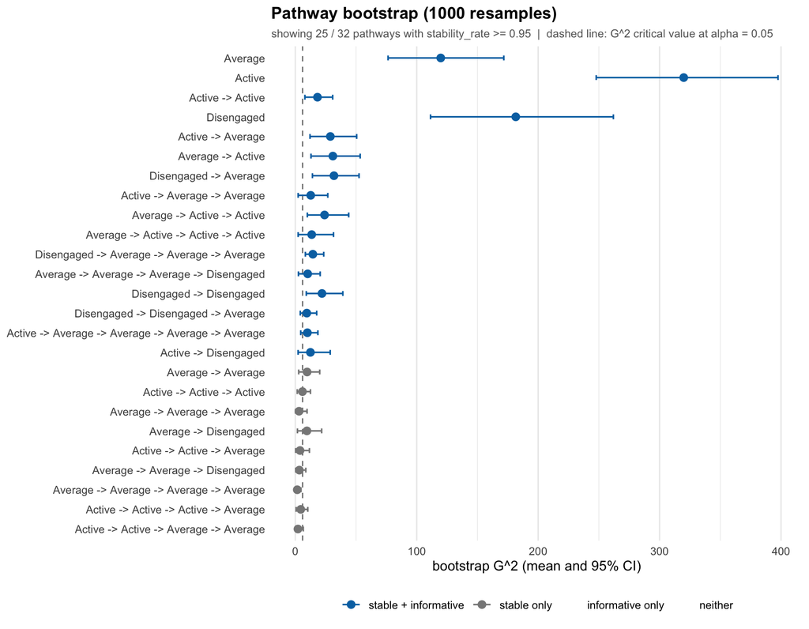

```r
plot(boot)
```

> The bootstrap refits the tree on resampled learners and asks which pathways survive *reproducibly*. The forest plot shows each pathway’s bootstrap interval against the significance line; a bar entirely to the right is reproducibly informative. The pathways that are both stable and informative are the ones worth building a claim on.

# Other views of the same tree

[figure not shown]

```r
plot(pruned, style = "icicle")
```

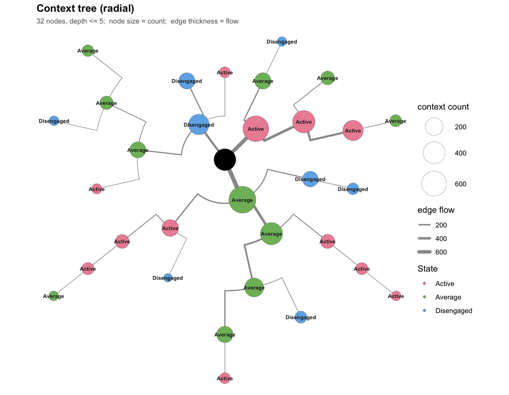

```r
plot(pruned, style = "dendrogram")
```